Notebook created by Jan Gądek  
modified by Magdalena Rybicka

**Digital Signal Processing Lab**

**IIR Filters**

# Introduction

The infinite impulse response (IIR) filter is a recursive filter in that the output from the filter is computed by using the current and previous inputs and previous outputs. In this notebook you will have to implement a few exercises that will help you get acquainted with the subject of IIR filters.

Before working with the notebook, you might find it useful to become acquainted with the following materials:

- Section **11.1 Wymagania stawiane filtrom cyfrowym** from “Cyfrowe przetwarzanie sygnałów : od teorii do zastosowań, WKŁ 2014” by T. P. Zieliński.
- Section **11.3 Metoda niezmienności odpowiedzi impulsowej** from “Cyfrowe przetwarzanie sygnałów : od teorii do zastosowań, WKŁ 2014” by T. P. Zieliński.
- Section **11.5 Metoda transformacji biliniowej** from “Cyfrowe przetwarzanie sygnałów : od teorii do zastosowań, WKŁ 2014” by T. P. Zieliński.

# Necessary imports

You should not import anything else in order to complete exercises in this notebook.

```python
# NumPy package
import numpy as np

# Matplotlib for plotting figures
import matplotlib.pyplot as plt

# Signal processing package
import scipy.signal as sig
```

# Practical problem set

## BIBO Stability

The transfer function allows us to assess whether or not a system instable. To be specific, the stability criteria requires that the [ROC](https://en.wikipedia.org/wiki/Infinite_impulse_response#Stability) of the system includes the unit circle. For example, for a causal system, all poles of the transfer function have to have an absolute value smaller than one. In other words, all poles must be located within a unit circle in the plane.

### Exercise

Implement function that will check if IIR filter is stable.

**Note**: Similar exercise was presented in Assignment 5 (Discrete LTI Systems). Therefore, in this exercise you can reuse your previously implemented function.

```python
def check_stability(de, no):
    """
    This function checks stability of a filter.

    Parameters
    ----------
    de: numpy array containing denominator of IIR transmitance.
    no: numpy array containing nominator of IIR transmitance.

    Returns
    -------
    True or False (or 1/0)

    """
    poles=np.roots(de)

    a=0
    for i in range(poles.size):
        if np.abs(poles[i])>1:
            a+=1

    if a==0:
        return True
    else:
        return False
```

```python
z, p ,k = sig.iirfilter(3, [0.6, 0.7], btype = 'bandpass', output='zpk')
print(np.sort(np.abs(p)))

no, de= sig.iirfilter(3, [0.6, 0.7], btype = 'bandpass')
poles=np.roots(de)
print(np.sort(np.abs(poles)))
```

```
[0.85237464 0.85237464 0.91999706 0.91999706 0.93018561 0.93018561]
[0.85237464 0.85237464 0.91999706 0.91999706 0.93018561 0.93018561]
```

Verify your implementation:

```python
# Stable filter design
no1, de1 = sig.iirfilter(3, [0.6, 0.7], btype = 'bandpass')

# Unstable filter design
no2, de2 = sig.iirfilter(84, 0.5, btype = 'lowpass')

# Checking stability using your implementation
stable = check_stability(de1,no1)
unstable = check_stability(de2,no2)

print('Your result for a stable filter is: ', stable, '\nYour result for an unstable filter is: ', unstable)
print('Your implementation succeeded' if stable and not unstable else 'Your implementation doesn`t work correctly')
```

```
Your result for a stable filter is:  True
Your result for an unstable filter is:  False
Your implementation succeeded
```

## IIR Frequency response

Frequency response of the IIR filter can be calculated using following formula:

$$ \large h(f_{n}) = \frac{\sum_{n=0}^{N} b_{n} e^{{-j2\pi nf_n}}}{1+\sum_{n=1}^{N} a_{n} e^{{-j2\pi nf_n}}} $$

where:

- $a(n)$ is n`th coefficient of the denominator of the filter transmitance
- $b(n)$ is n`th coefficient of the numerator of the filter transmitance
- $f_n$ is normalized frequency from 0 to 1
- $N$ is number of points at which frequency response will be calculated

### Exercise

Implement a function that will calculate frequency response of an IIR filter in a given number of points using above formula. Frequency response should be calculated only from 0 to Nyquist frequency!

```python
def freqz(no, de, worN=512):
    """
    This function calculate frequency response of an IIR filter.

    Parameters
    ----------
    de: numpy array containing denominator of IIR transmitance.
    no: numpy array containing numerator of FIR transmitance.
    worN: int containing number of samples at which frequency response is calculated.

    Returns
    -------
    h: numpy array containing frequency response of a filter

    """
    f_n=np.linspace(0,0.5,worN) #normalized frequency

    h=np.zeros(worN,dtype=complex)

    for i in range(worN):
        L=0
        M=1
        for n in range(no.size):
            L+=no[n]*np.exp(-2j*np.pi*n*f_n[i])
        for n in range(1,de.size):
            M+=de[n]*np.exp(-2j*np.pi*n*f_n[i])
        h[i]=L/M

    return h
```

Verify your implementation.

```
Your implementation succeeded!
```

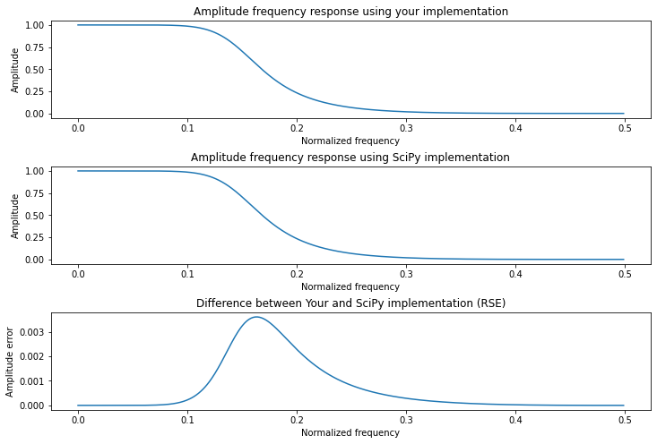

```python
# IIR filter design
no, de = sig.iirfilter(4, 0.3, btype = 'lowpass')

# Calculating frequency response using your implementation
h = freqz(no, de, 512)
# Normalization
h = h / np.max(np.abs(h[0]))

# Calculating frequency response using SciPy implementation
w, h_ref = sig.freqz(no, de)
# Normalization
h_ref = h_ref / np.max(np.abs(h_ref[0]))

# Calculating error
RMSE = np.sum(np.abs(h) - np.abs(h_ref))

print('Your implementation succeeded!' if RMSE < 1 else 'Error is a little to big')

plt.figure(figsize = (12,8))

plt.subplot(3,1,1)
plt.plot(w/np.pi/2, np.abs(h))
plt.xlabel('Normalized frequency' )
plt.ylabel('Amplitude')
plt.title('Amplitude frequency response using your implementation')

plt.subplot(3,1,2)
plt.plot(w/np.pi/2, np.abs(h_ref))
plt.xlabel('Normalized frequency' )
plt.ylabel('Amplitude')
plt.title('Amplitude frequency response using SciPy implementation')

plt.subplot(3,1,3)
plt.plot(w/np.pi/2, np.abs(h_ref) - np.abs(h))
plt.xlabel('Normalized frequency')
plt.ylabel('Amplitude error')
plt.title('Difference between Your and SciPy implementation (RSE)')

plt.subplots_adjust(hspace=0.5)
plt.show()
```

## IIR impulse response

```python
def draw_IIR(de, no, nsamples):
    """
    This function draws IIR impulse response, frequency amplitude response and poles and zeros on the z-plane.
    This function uses Your implementation of check_stability and freqz functions!!!

    Parameters
    ----------
    de: numpy array containing denominator of IIR transmitance.
    no: numpy array containing numerator of FIR transmitance.
    nsamples: int containing number of samples at which impulse response is calculated.
    """
    print('\nDrawing begin, filter is stable. \n' if check_stability(de,no) else '\nDrawing begin, filter is unstable. \n')

    # Ploting zeros and poles
    zeros, poles, gain = sig.tf2zpk(no, de)
    t = np.linspace(0, 2*np.pi, 200)
    axes = np.max((np.max(np.abs(zeros)), np.max(np.abs(poles)), 1.5))

    plt.figure(figsize = (18,12))

    # Ploting unit circle zeros and poles
    plt.subplot(1,2,2)
    plt.plot(np.cos(t), np.sin(t), 'c--', linewidth=2)
    plt.plot(np.real(zeros), np.imag(zeros), 'ro', linewidth=4)
    plt.plot(np.real(poles), np.imag(poles), 'bx', linewidth=4)
    plt.xlabel('Imagine part')
    plt.ylabel('Real part')
    plt.legend(('Unit cicle', 'Zeros', 'Poles'))
    plt.xlim(-axes, axes)
    plt.ylim(-1.5*axes, 1.5*axes)

    # Ploting impulse response
    times = np.linspace(0,nsamples,100)
    IR = np.array(sig.impulse((no, de), T=times))

    plt.subplot(2,2,1)
    plt.plot(IR[0], IR[1])
    plt.title('Filter impulse response')
    plt.xlabel('Time in samples')
    plt.ylabel('Amplitudes')

    # Ploting frequency response
    h = freqz(no,de,512)
    t = np.linspace(0,0.5,512)

    plt.subplot(2,2,3)
    plt.plot(t, np.abs(h))
    plt.title('Filter frequency amplitude response')
    plt.xlabel('Normalized frequency')
    plt.ylabel('Amplitudes')
    plt.show()

    print('\nDrawing finished\n')
    return
```

```
Drawing begin, filter is stable.
```

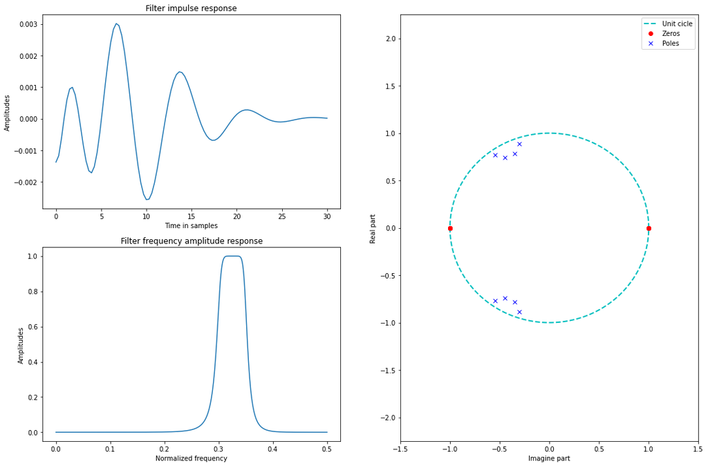

```
Drawing finished


Drawing begin, filter is unstable.
```

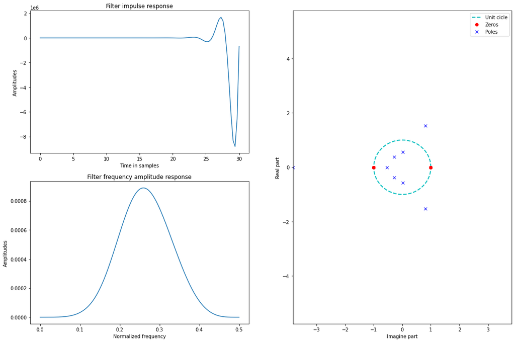

```
Drawing finished
```

```python
nsamples = 30

# Stable filter design
no1, de1 = sig.iirfilter(4, [0.6, 0.7], btype = 'bandpass')

# Unstable filter design
no2 = no1.copy()
de2 = de1.copy()

# Changing one coefficient of filter
a1 = -0.001
de2[2] = a1

# Drawing stable filter characteristics
draw_IIR(de1, no1, nsamples)

# Drawing unstable filter characteristics
draw_IIR(de2, no2, nsamples)
```

### Questions

- What is the difference between the impulse responses of these two filters?
- What is the differences in location of poles and zeros?
- What would happen if we applied these filters to audio?

```
-in stable filter, response gradually fades to achive 0, in unstable filter there occur undesired oscilations
-poles are located inside of unit square, zeros are located on the edge of unit square
-since we are using band-pass filter, first filter would "return" only frequencies from selected band, it would probably be drowned out since we are using such tight band, second filter would be unusable due to unstability
```

## Practical IIR design

### Exercise

- Using [scipy.signal.iirfilter](https://docs.scipy.org/doc/scipy/reference/generated/scipy.signal.iirfilter.html) (or other) function design Butterworth, Chebyshev type I, Chebyshev type II and Eliptic 4th order lowpass filter. Its normalized cutoff frequency should be 0.3.
- Draw frequency responses of all these filters on one plot.
- Try to choose the parameters (without changing filter order) of individual filters so that the frequency responses are as similar as possible

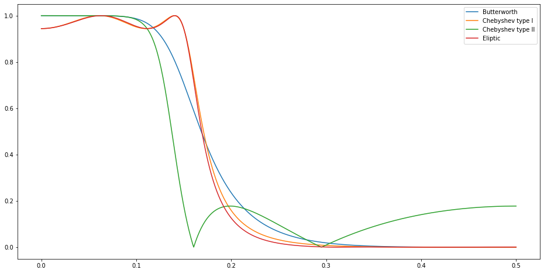

```python
no_butter,de_butter=sig.iirfilter(4,0.3,btype='lowpass',ftype='butter') #creating nominators and denominators of filters
no_che1,de_che1=sig.iirfilter(4,0.3,rp=0.5,btype='lowpass',ftype='cheby1')
no_che2,de_che2=sig.iirfilter(4,0.3,rs=15,btype='lowpass',ftype='cheby2')
no_eliptic,de_eliptic=sig.iirfilter(4,0.3,rp=0.5,rs=60,btype='lowpass',ftype='ellip')

butter=freqz(no_butter,de_butter, worN=512) #creating filters
che1=freqz(no_che1,de_che1, worN=512)
che2=freqz(no_che2,de_che2, worN=512)
eliptic=freqz(no_eliptic,de_eliptic, worN=512)

fig=plt.figure(figsize = (16,8)) #plotting
plt.plot(np.linspace(0,0.5,512),np.abs(butter),label='Butterworth')
plt.plot(np.linspace(0,0.5,512),np.abs(che1),label='Chebyshev type I')
plt.plot(np.linspace(0,0.5,512),np.abs(che2),label='Chebyshev type II')
plt.plot(np.linspace(0,0.5,512),np.abs(eliptic),label='Eliptic')
plt.legend()
```

### Questions

- Characterize each type of filter in one sentence (note differences, advantages, disadvantages, tradeoffs).

```
-Butterworth: least complicated, probably least effective
-Chebyshev Type I: ok drop, unwanted distortions occuring righ before cutoff frequency
-Chebyshev Type II: very sharp jump to 0, "leaks" when zero is achieved
-Eliptic: inherits some of the advantagees of Chebyshev, an ok, sharp drop but also it comes with previously mentioned   distortions
```

### Exercise

- For AT LEAST two choosen types of filters from previous exercise:
  - Design 2'nd, 6'th and 60'th order filter.
  - Check stability of those filters using your implementation of check_stability function.
  - Draw its frequency responses on one plot
  - Draw its poles and zeros on the separate plots.

You should end up with 8 plots total. You can use draw_IIR function or its part.

[output not shown]

```
Low-pass Butterworth filter
    Stability:
	 2nd order True
	 6th order True
	 60th order False
Low-pass Eliptic filter
    Stability:
	 2nd order True
	 6th order True
	 60th order False
```

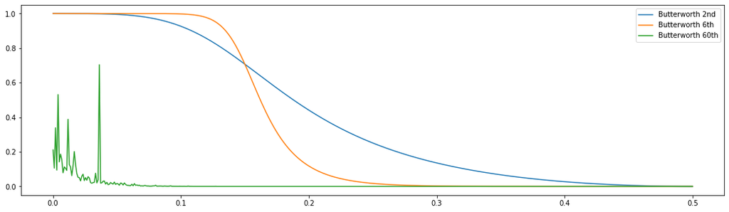

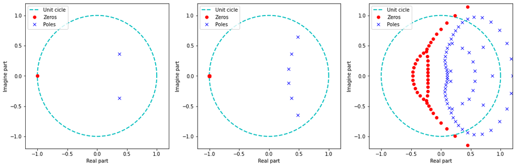

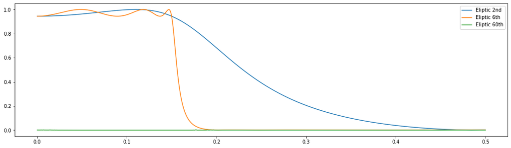

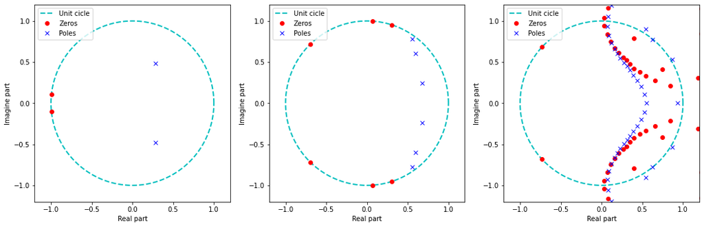

```python
no_b_2,de_b_2=sig.iirfilter(2,0.3,btype='lowpass',ftype='butter')  #creating nominators and denominators
no_b_6,de_b_6=sig.iirfilter(6,0.3,btype='lowpass',ftype='butter')
no_b_60,de_b_60=sig.iirfilter(60,0.3,btype='lowpass',ftype='butter')

z_b_2,p_b_2,k_b_2=sig.tf2zpk(no_b_2,de_b_2)  #calculating zeros, poles and gain
z_b_6,p_b_6,k_b_6=sig.tf2zpk(no_b_6,de_b_6)
z_b_60,p_b_60,k_b_60=sig.tf2zpk(no_b_60,de_b_60)

butter_2=freqz(no_b_2,de_b_2,worN=512)  #creating filters
butter_6=freqz(no_b_6,de_b_6,worN=512)
butter_60=freqz(no_b_60,de_b_60,worN=512)

t = np.linspace(0, 2*np.pi, 200) #used for creating circle

z_b=[z_b_2,z_b_6,z_b_60]
p_b=[p_b_2,p_b_6,p_b_60]

print('Low-pass Butterworth filter','\n   ','Stability:') #checking stability
print('\t 2nd order',check_stability(de_b_2,no_b_2),'\n\t 6th order',check_stability(de_b_6,no_b_6),'\n\t 60th order',check_stability(de_b_60,no_b_60))

fig=plt.figure(figsize=(18,5))  #plotting frequency response
plt.plot(np.linspace(0,0.5,512),np.abs(butter_2),label='Butterworth 2nd')
plt.plot(np.linspace(0,0.5,512),np.abs(butter_6),label='Butterworth 6th')
plt.plot(np.linspace(0,0.5,512),np.abs(butter_60),label='Butterworth 60th')
plt.legend()

fig=plt.figure()  #plotting zeros and poles inside unit square
fig, axes = plt.subplots(figsize=(18,5.5),nrows=1, ncols=3)


for i in range(3):
    axes[i].plot(np.cos(t), np.sin(t), 'c--', linewidth=2)
    axes[i].plot(np.real(z_b[i]), np.imag(z_b[i]), 'ro', linewidth=4)
    axes[i].plot(np.real(p_b[i]), np.imag(p_b[i]), 'bx', linewidth=4)
    axes[i].set_ylabel('Imagine part')
    axes[i].set_xlabel('Real part')
    axes[i].legend(('Unit cicle', 'Zeros', 'Poles'),loc=2)
    axes[i].set_xlim(-1.2, 1.2)
    axes[i].set_ylim(-1.2, 1.2)

#############################################################################################

no_e_2,de_e_2=sig.iirfilter(2,0.3,rp=0.5,rs=60,btype='lowpass',ftype='ellip')
no_e_6,de_e_6=sig.iirfilter(6,0.3,rp=0.5,rs=60,btype='lowpass',ftype='ellip')
no_e_60,de_e_60=sig.iirfilter(60,0.3,rp=0.5,rs=60,btype='lowpass',ftype='ellip')

z_e_2,p_e_2,k_e_2=sig.tf2zpk(no_e_2,de_e_2)
z_e_6,p_e_6,k_e_6=sig.tf2zpk(no_e_6,de_e_6)
z_e_60,p_e_60,k_e_60=sig.tf2zpk(no_e_60,de_e_60)

ellip_2=freqz(no_e_2,de_e_2,worN=512)
ellip_6=freqz(no_e_6,de_e_6,worN=512)
ellip_60=freqz(no_e_60,de_e_60,worN=512)

z_e=[z_e_2,z_e_6,z_e_60]
p_e=[p_e_2,p_e_6,p_e_60]

print('Low-pass Eliptic filter','\n   ','Stability:')
print('\t 2nd order',check_stability(de_e_2,no_e_2),'\n\t 6th order',check_stability(de_e_6,no_e_6),'\n\t 60th order',check_stability(de_e_60,no_e_60))

fig=plt.figure(figsize=(18,5))
plt.plot(np.linspace(0,0.5,512),np.abs(ellip_2),label='Eliptic 2nd')
plt.plot(np.linspace(0,0.5,512),np.abs(ellip_6),label='Eliptic 6th')
plt.plot(np.linspace(0,0.5,512),np.abs(ellip_60),label='Eliptic 60th')
plt.legend()

fig=plt.figure()
fig, axes = plt.subplots(figsize=(18,5.5),nrows=1, ncols=3)

for i in range(3):
    axes[i].plot(np.cos(t), np.sin(t), 'c--', linewidth=2)
    axes[i].plot(np.real(z_e[i]), np.imag(z_e[i]), 'ro', linewidth=4)
    axes[i].plot(np.real(p_e[i]), np.imag(p_e[i]), 'bx', linewidth=4)
    axes[i].set_ylabel('Imagine part')
    axes[i].set_xlabel('Real part')
    axes[i].legend(('Unit cicle', 'Zeros', 'Poles'),loc=2)
    axes[i].set_xlim(-1.2, 1.2)
    axes[i].set_ylim(-1.2, 1.2)
```

### Questions

- What happens if we use to low order filtration
- What happens if we use to high order filtration

```
-low order filtration is uneffective but pretty much guarantees stability of the system
-high order filtration, when order picked appropriately, is much more efficient, even though it has a risk of being unstable
```